## ASSIGNMENT 1

```r
df<-read.csv("activity.csv")
```

##### What is mean total number of steps taken per day?

Make a histogram of the total number of steps taken each day:

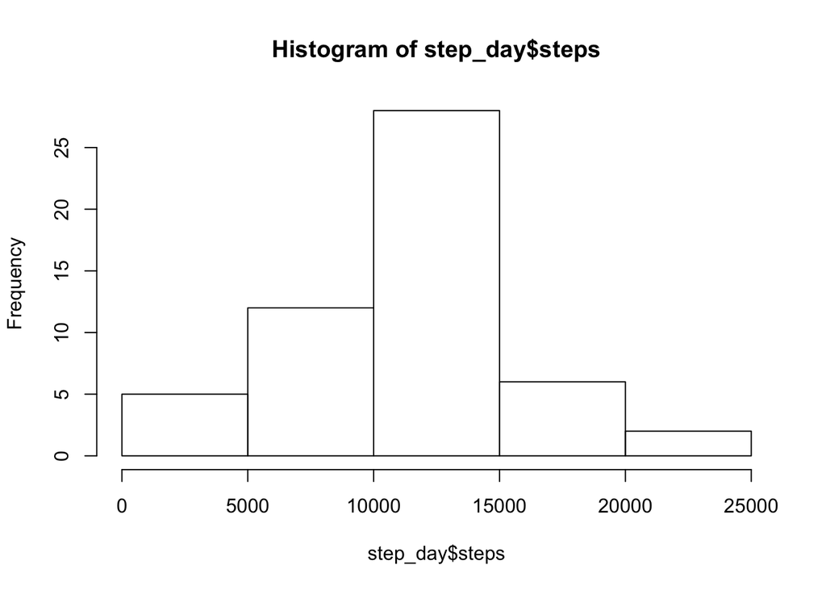

```r
##Create a new dataframe that sums the total steps taken each day
step_day <- aggregate(steps~date,df,sum)
##Create a historgram of steps taken each day
hist(step_day$steps)
```

Calculate and report the mean and median total number of steps taken per day:

```r
mean(step_day$steps, na.rm=TRUE)
```

```
## [1] 10766
```

```r
median(step_day$steps, na.rm=TRUE)
```

```
## [1] 10765
```

##### What is the average daily activity pattern?

Make a time series plot (i.e. type = “l”) of the 5-minute interval (x-axis) and the average number of steps taken, averaged across all days (y-axis).

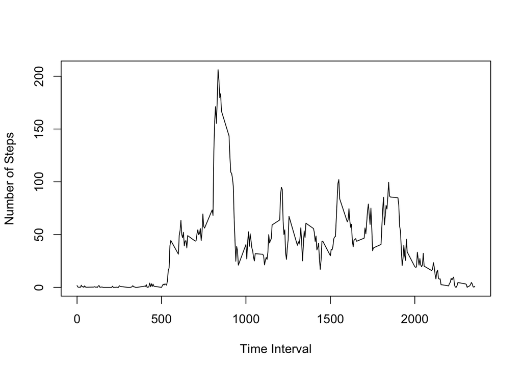

```r
##Calculate the average number of steps taken during each time interval
intervals <- aggregate(steps~interval, df, mean)
plot(intervals$interval, intervals$steps, type="l", xlab="Time Interval", ylab="Number of Steps")
```

Which 5-minute interval, on average across all the days in the dataset, contains the maximum number of steps?

```r
intervals$interval[match(max(intervals$steps, na.rm=TRUE), intervals$steps)]
```

```
## [1] 835
```

##### Imputing missing values

Calculate and report the total number of missing values in the dataset (i.e. the total number of rows with NAs)

```r
sum(is.na(df$steps))
```

```
## [1] 2304
```

Devise a strategy for filling in all of the missing values in the dataset. The strategy does not need to be sophisticated. For example, you could use the mean/median for that day, or the mean for that 5-minute interval, etc.

Create a new dataset that is equal to the original dataset but with the missing data filled in.

```r
###The df_modified dataset fills in missing values in the original dataset with the average value of that particular time interval.
df_modified <- df
df_modified$steps[is.na(df_modified$steps)] <- intervals$steps[match(df_modified$interval, intervals$interval)]
```

Make a histogram of the total number of steps taken each day and Calculate and report the mean and median total number of steps taken per day.

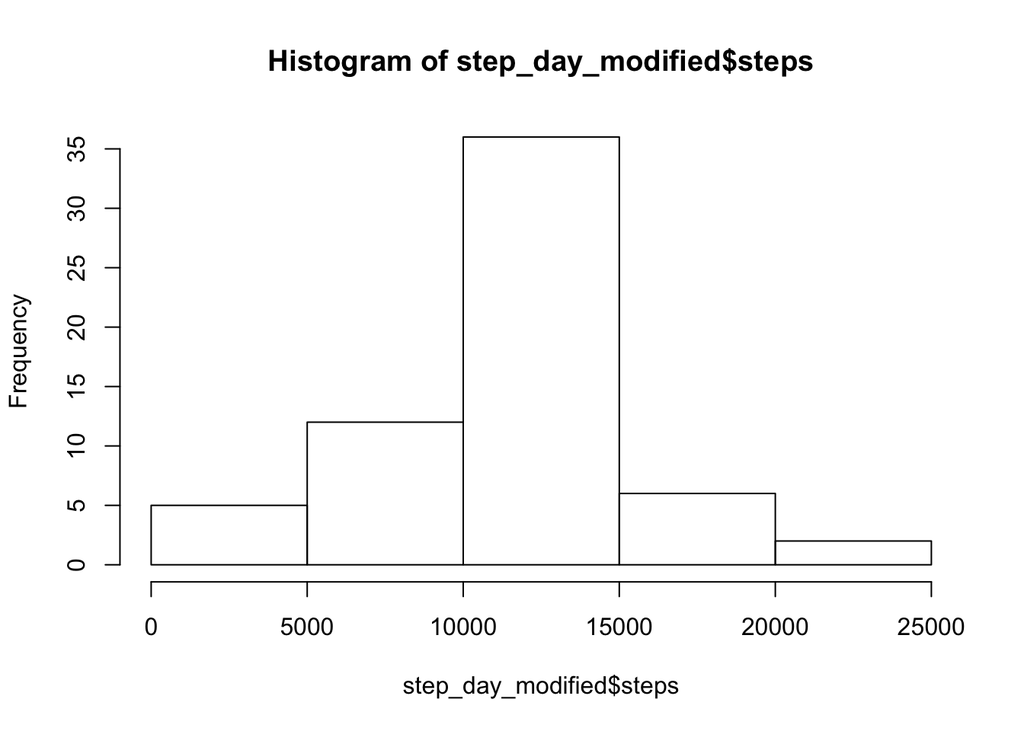

```r
##Create a new dataframe that sums the total steps taken each day
step_day_modified <- aggregate(steps~date,df_modified,sum)
##Create a historgram of steps taken each day
hist(step_day_modified$steps)
```

```r
##Calculate the mean and median of the number of steps taken each day
mean(step_day_modified$steps, na.rm=TRUE)
```

```
## [1] 10766
```

```r
median(step_day_modified$steps, na.rm=TRUE)
```

```
## [1] 10766
```

##### Do these values differ from the estimates from the first part of the assignment? What is the impact of imputing missing data on the estimates of the total daily number of steps?

The mean is unchanged after imputing the missing values for specific intervals. This makes sense after confirming that interval values were missing only for complete days; there were not days that had a mix of real data and missing values. Because we imputted full-days worth of mean data, albeit broken up into intervals, it follows that the number of steps for those days would work out to the daily average before the imputation. The median, however, adjusts slightly due to the fact that we’ve introduced data for several missing days–the new data we’ve imputted is the same for each of those days.

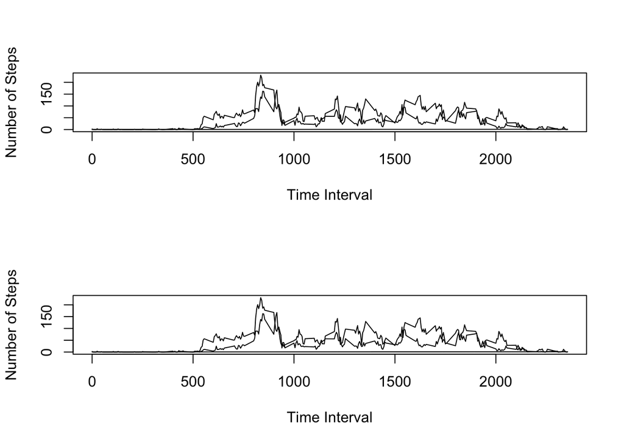

```r
##Convert the 'date' field from factor to date
df_modified$date <- as.Date(df_modified$date)

##If the date is a weekday, return "Weekday", if it's a weekend, return "Weekend"
df_modified$weekday <- ifelse(weekdays(df_modified$date) == "Saturday", "Weekend", ifelse(weekdays(df_modified$date)== "Sunday", "Weekend", "Weekday"))

#Calculate the number of steps taken during each interval, averaged across weekday days or weekend days
df_modified$interval_weekday <- paste(df_modified$interval, df_modified$weekday, sep="_")
intervals2 <- aggregate(steps~interval_weekday, df_modified, mean)
##Bring the calculated averages back into the df_modified datafram in a new field
df_modified$avg_int_day <- intervals2$steps[match(df_modified$interval_weekday, intervals2$interval_weekday)]
##Subset the data to isolate interval/weekday pairs
df_modified <- subset(df_modified, !duplicated(df_modified$interval_weekday), select=steps:avg_int_day)

#Create the panel plot
with(df_modified[df_modified$weekday=="Weekday",], plot(df_modified$interval, df_modified$avg_int_day, type="l", xlab="Time Interval", ylab="Number of Steps"))

par(mfrow=c(2,1))
plot(df_modified$interval, df_modified$avg_int_day, type="l", xlab="Time Interval", ylab="Number of Steps")
plot(df_modified$interval, df_modified$avg_int_day, type="l", xlab="Time Interval", ylab="Number of Steps")
```